# R_For_Data_Science_Notes

Abhishek Dangol

12/30/2019

## The mpg data frame

First we need to load the ggplot2 package. ‘mpg’ is a dataset in the ggplot2 library.

```r
library(ggplot2)
mpg
```

```
## # A tibble: 234 x 11
##    manufacturer model displ  year   cyl trans drv     cty   hwy fl    class
##    <chr>        <chr> <dbl> <int> <int> <chr> <chr> <int> <int> <chr> <chr>
##  1 audi         a4      1.8  1999     4 auto~ f        18    29 p     comp~
##  2 audi         a4      1.8  1999     4 manu~ f        21    29 p     comp~
##  3 audi         a4      2    2008     4 manu~ f        20    31 p     comp~
##  4 audi         a4      2    2008     4 auto~ f        21    30 p     comp~
##  5 audi         a4      2.8  1999     6 auto~ f        16    26 p     comp~
##  6 audi         a4      2.8  1999     6 manu~ f        18    26 p     comp~
##  7 audi         a4      3.1  2008     6 auto~ f        18    27 p     comp~
##  8 audi         a4 q~   1.8  1999     4 manu~ 4        18    26 p     comp~
##  9 audi         a4 q~   1.8  1999     4 auto~ 4        16    25 p     comp~
## 10 audi         a4 q~   2    2008     4 manu~ 4        20    28 p     comp~
## # ... with 224 more rows
```

We want to find out if cars with bigger engines consume more gas. The geom_point() adds a layer of points to the plot (scatterplot) Each geom function in ggplot takes a mapping as argument. This defines how variables in dataset are mapped to visual properties. The mapping argument is always paired with aes() and the x and y arguments of aes() specify which variables to map to the x and y axes.

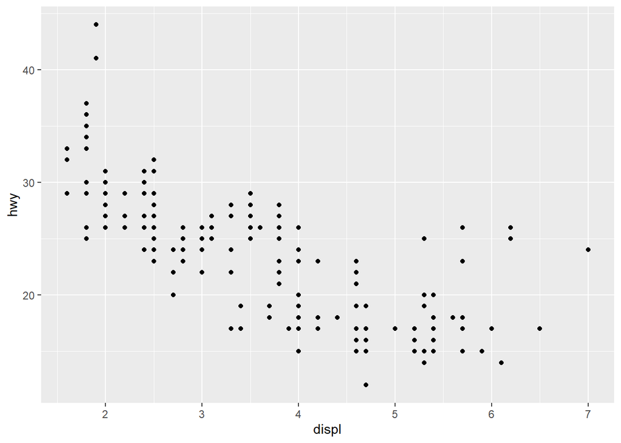

```r
ggplot(data=mpg) + geom_point(mapping = aes(x = displ, y = hwy))
```

## Aesthetic mapping

We can map the colors of our points to the ‘class’ variable to reveal the class of each car. As we cam see the red dots are sports cars and hence, they have better mileage despite having bigger engines.

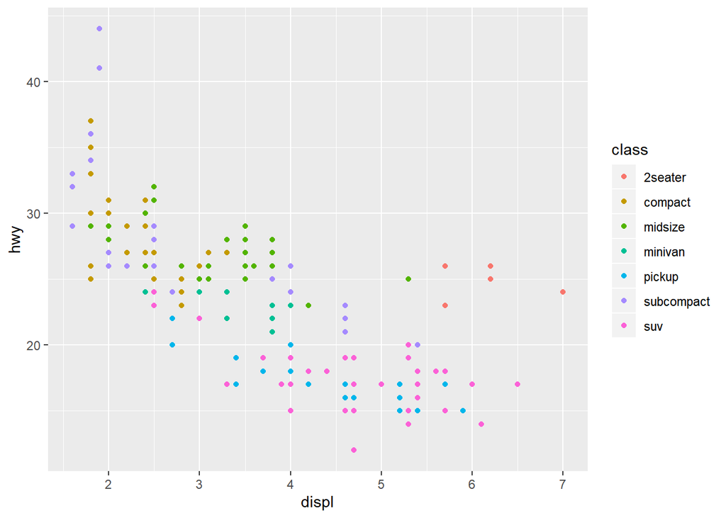

```r
ggplot(data = mpg) + geom_point(mapping = aes(x = displ, y = hwy, color = class))
```

Alternatively, we can also map class to the alpha aesthetic which controls the transparency of the points or to the shape aesthetic which controls the shape of the points/

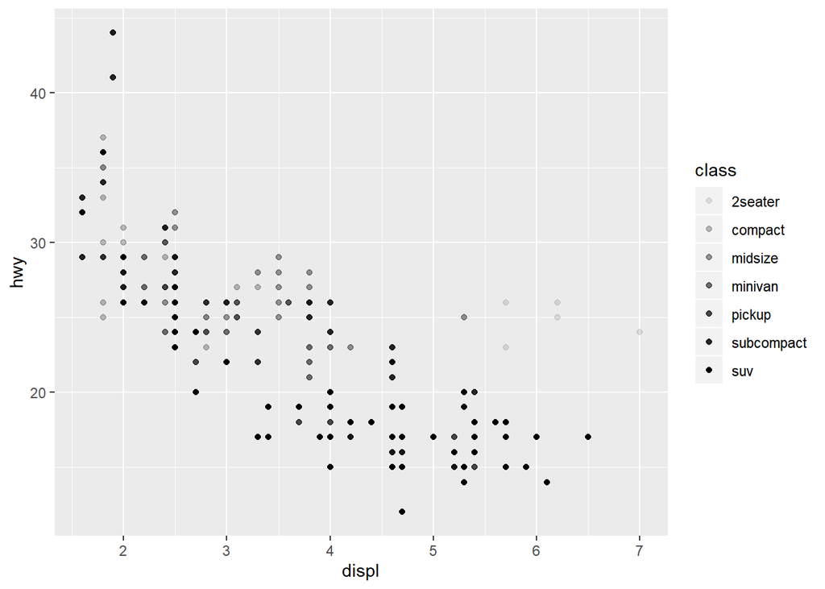

```r
ggplot(data = mpg) + geom_point(mapping = aes(x = displ, y = hwy, alpha = class))
```

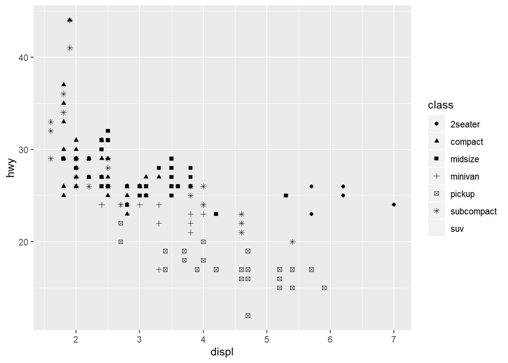

```r
ggplot(data = mpg) + geom_point(mapping = aes(x = displ, y = hwy, shape = class))
```

We can also set the aesthetic property of the geom manually. For example, we can make all of the points in our plot blue.

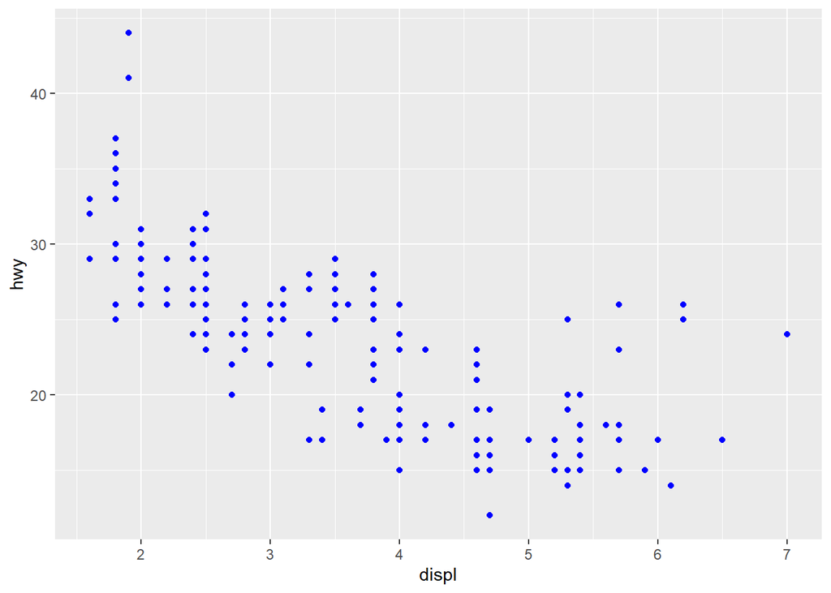

```r
ggplot(data = mpg) + geom_point(mapping = aes(x = displ, y = hwy), color = "blue")
```